# Reproducible Research Course Project 1

Ronald

01 Aug 2020

## Introduction

It is now possible to collect a large amount of data about personal movement using activity monitoring devices such as a Fitbit, Nike Fuelband, or Jawbone Up. These type of devices are part of the “quantified self” movement – a group of enthusiasts who take measurements about themselves regularly to improve their health, to find patterns in their behavior, or because they are tech geeks. But these data remain under-utilized both because the raw data are hard to obtain and there is a lack of statistical methods and software for processing and interpreting the data.

This assignment makes use of data from a personal activity monitoring device. This device collects data at 5 minute intervals through out the day. The data consists of two months of data from an anonymous individual collected during the months of October and November, 2012 and include the number of steps taken in 5 minute intervals each day.

## Loading and preprocessing the data

```r
#Load Libraries
library(tidyverse)
#Read csv
activity <- read.csv("activity.csv")

#Convert to date
activity$date <- as.Date(activity$date, "%Y-%m-%d")

#View dataset structure
str(activity)
```

```
## 'data.frame':    17568 obs. of  3 variables:
##  $ steps   : int  NA NA NA NA NA NA NA NA NA NA ...
##  $ date    : Date, format: "2012-10-01" "2012-10-01" ...
##  $ interval: int  0 5 10 15 20 25 30 35 40 45 ...
```

## What is mean total number of steps taken per day?

### Calculate the total number of steps taken per day

```r
#Aggregate data
agg_sum <- aggregate(steps ~ date, activity, sum)

#View data
head(agg_sum)
```

```
##         date steps
## 1 2012-10-02   126
## 2 2012-10-03 11352
## 3 2012-10-04 12116
## 4 2012-10-05 13294
## 5 2012-10-06 15420
## 6 2012-10-07 11015
```

### Histogram of the total number of steps taken each day

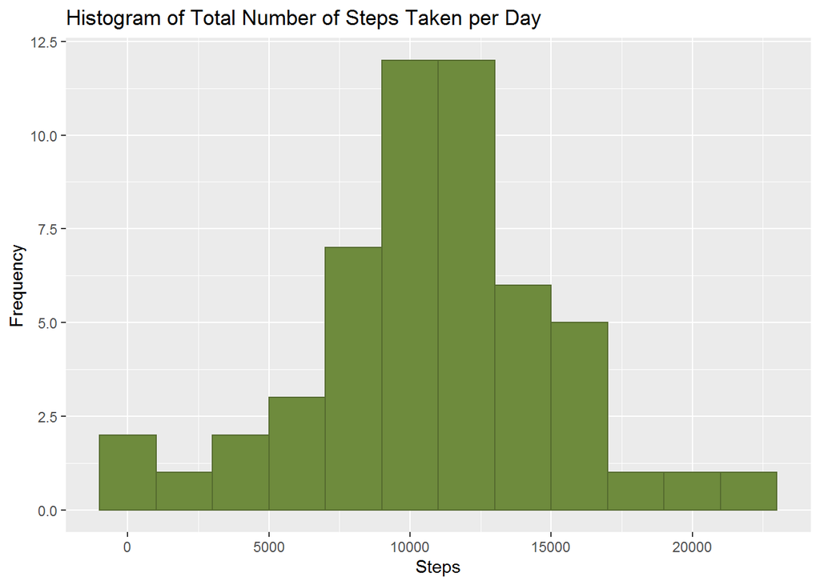

```r
#Plot Histogram
ggplot(agg_sum, aes(steps)) +
  ggtitle("Histogram of Total Number of Steps Taken per Day") +
  xlab("Steps") +
  ylab("Frequency") +
  geom_histogram(binwidth = 2000,
                 color = "Dark Olive Green",
                 fill = "darkolivegreen4")
```

### Calculate and report the mean and median of the total number of steps taken per day

```r
#Mean steps
mean(agg_sum$steps)
```

```
## [1] 10766.19
```

```r
#Median steps
median(agg_sum$steps)
```

```
## [1] 10765
```

## What is the average daily activity pattern?

### Time series plot of the average number of steps taken

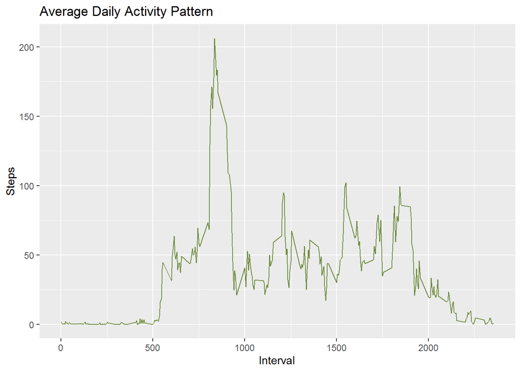

```r
#Aggregate Data
agg_mean <- aggregate(steps ~ interval, activity, mean)

#Plot Histogram
ggplot(agg_mean, aes(x = interval, y = steps)) +
  ggtitle("Average Daily Activity Pattern") +
  xlab("Interval") +
  ylab("Steps") +
  geom_line(color = "darkolivegreen4")
```

### The 5-minute interval that, on average, contains the maximum number of steps

```r
#Find the interval with max steps
agg_mean$interval[agg_mean$steps == max(agg_mean$steps)]
```

```
## [1] 835
```

## Imputing missing values

### Calculate and report the total number of missing values in the dataset (i.e. the total number of rows with NAs)

```r
#Count the no. of NA
sum(is.na(activity$steps))
```

```
## [1] 2304
```

### Impute missing values using the mean for that 5-minute interval

```r
#Create new dataframe for imputed data
activity_imputed <- activity

#Look for the mean for that 5-minute interval
join_data <- left_join(activity, agg_mean, by = "interval")

#Replace NAs
activity_imputed$steps[is.na(activity_imputed$steps)] <- join_data$steps.y[is.na(join_data$steps.x)]

#View data
head(activity_imputed)
```

```
##       steps       date interval
## 1 1.7169811 2012-10-01        0
## 2 0.3396226 2012-10-01        5
## 3 0.1320755 2012-10-01       10
## 4 0.1509434 2012-10-01       15
## 5 0.0754717 2012-10-01       20
## 6 2.0943396 2012-10-01       25
```

### Histogram of the total number of steps taken each day

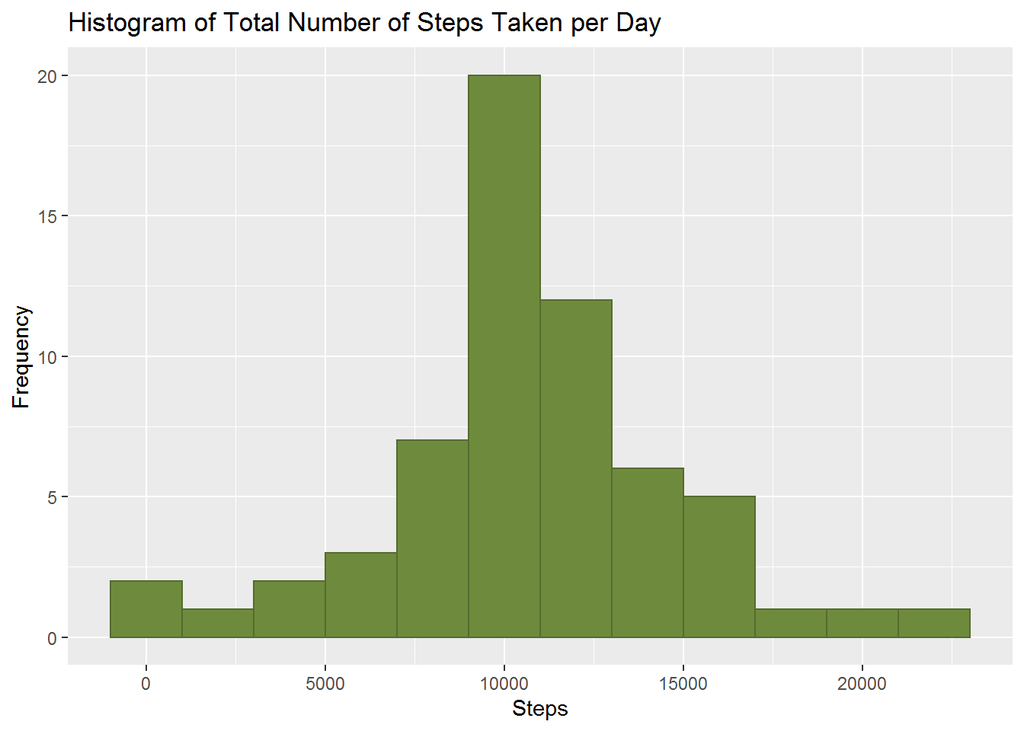

```r
#Aggregate data
agg_imputed_sum <- aggregate(steps ~ date, activity_imputed, sum)

#Plot Histogram
ggplot(agg_imputed_sum, aes(steps)) +
  ggtitle("Histogram of Total Number of Steps Taken per Day") +
  xlab("Steps") +
  ylab("Frequency") +
  geom_histogram(binwidth = 2000,
                 color = "Dark Olive Green",
                 fill = "darkolivegreen4")
```

### Report the mean and median total number of steps taken per day

```r
#Calculate Mean
mean(agg_imputed_sum$steps)
```

```
## [1] 10766.19
```

```r
#Calculate Median
median(agg_imputed_sum$steps)
```

```
## [1] 10766.19
```

### Do these values differ from the estimates from the first part of the assignment? What is the impact of imputing missing data on the estimates of the total daily number of steps?

```r
#Change in  Mean
mean(agg_imputed_sum$steps) - mean(agg_sum$steps)
```

```
## [1] 0
```

```r
#Change in Median
median(agg_imputed_sum$steps) - median(agg_sum$steps)
```

```
## [1] 1.188679
```

## Are there differences in activity patterns between weekdays and weekends?

### Create a new factor variable in the dataset with two levels – “weekday” and “weekend”

```r
#Translate date to weekdays
activity_imputed$weekday <- weekdays(activity_imputed$date)

#Filter out weekends
activity_imputed$weekday [activity_imputed$weekday == "Sunday" | activity_imputed$weekday == "Saturday"] <- "weekend"

#Filter out weekdays
activity_imputed$weekday [activity_imputed$weekday != "weekend"] <- "weekday"

#View data
head(activity_imputed)
```

```
##       steps       date interval weekday
## 1 1.7169811 2012-10-01        0 weekday
## 2 0.3396226 2012-10-01        5 weekday
## 3 0.1320755 2012-10-01       10 weekday
## 4 0.1509434 2012-10-01       15 weekday
## 5 0.0754717 2012-10-01       20 weekday
## 6 2.0943396 2012-10-01       25 weekday
```

### 5-minute interval (x-axis) and the average number of steps taken, averaged across all weekday days or weekend days (y-axis)

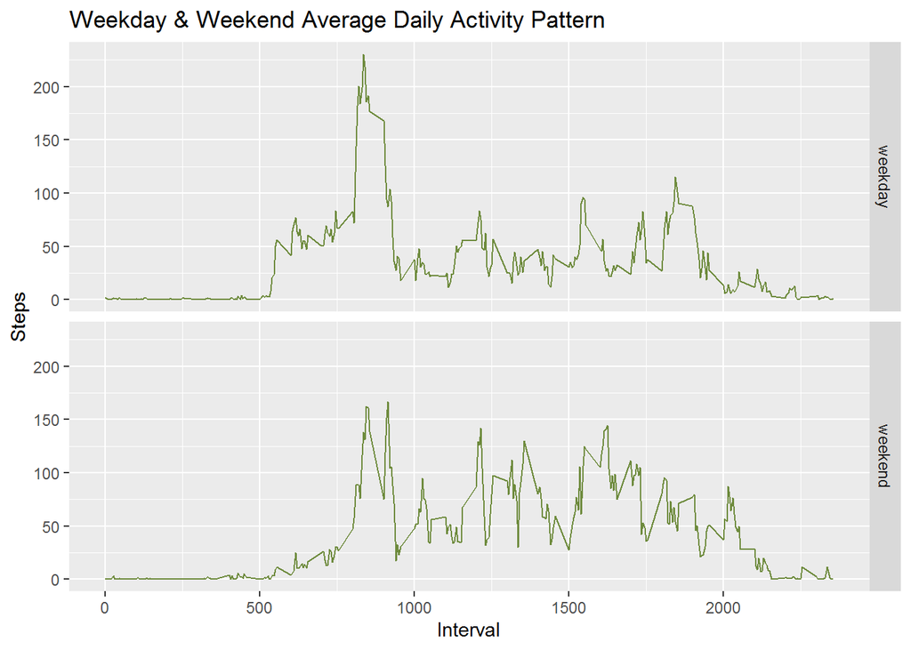

```r
#Aggregate data
agg_wkday <- aggregate(steps ~ interval + weekday, activity_imputed, mean)

#Plot line graph
ggplot(agg_wkday, aes(x = interval, y = steps)) +
  ggtitle("Weekday & Weekend Average Daily Activity Pattern") +
  xlab("Interval") +
  ylab("Steps") +
  geom_line(color = "darkolivegreen4") +
  facet_grid(weekday ~ .,)
```